# Untitled17-Copy2

```python
# Import libraries
import pandas as pd
import numpy as ny
import seaborn as sns
import matplotlib.pyplot as plt
```

```python
# Import data
df = pd.read_csv('/Users/liqin/Desktop/hotel/H2.csv')
df_raw = df.copy()  # Save original data set, just in case.
```

```python
# Overview
df.head()
```

|  | IsCanceled | LeadTime | ArrivalDateYear | ArrivalDateMonth | ArrivalDateWeekNumber | ArrivalDateDayOfMonth | StaysInWeekendNights | StaysInWeekNights | Adults | Children | ... | DepositType | Agent | Company | DaysInWaitingList | CustomerType | ADR | RequiredCarParkingSpaces | TotalOfSpecialRequests | ReservationStatus | ReservationStatusDate |
| --- | --- | --- | --- | --- | --- | --- | --- | --- | --- | --- | --- | --- | --- | --- | --- | --- | --- | --- | --- | --- | --- |
| 0 | 0 | 6 | 2015 | July | 27 | 1 | 0 | 2 | 1 | 0.0 | ... | No Deposit | 6 | NULL | 0 | Transient | 0.0 | 0 | 0 | Check-Out | 2015-07-03 |
| 1 | 1 | 88 | 2015 | July | 27 | 1 | 0 | 4 | 2 | 0.0 | ... | No Deposit | 9 | NULL | 0 | Transient | 76.5 | 0 | 1 | Canceled | 2015-07-01 |
| 2 | 1 | 65 | 2015 | July | 27 | 1 | 0 | 4 | 1 | 0.0 | ... | No Deposit | 9 | NULL | 0 | Transient | 68.0 | 0 | 1 | Canceled | 2015-04-30 |
| 3 | 1 | 92 | 2015 | July | 27 | 1 | 2 | 4 | 2 | 0.0 | ... | No Deposit | 9 | NULL | 0 | Transient | 76.5 | 0 | 2 | Canceled | 2015-06-23 |
| 4 | 1 | 100 | 2015 | July | 27 | 2 | 0 | 2 | 2 | 0.0 | ... | No Deposit | 9 | NULL | 0 | Transient | 76.5 | 0 | 1 | Canceled | 2015-04-02 |

5 rows × 31 columns

```python
df.index
```

```
RangeIndex(start=0, stop=79330, step=1)
```

```python
df.columns
```

```
Index(['IsCanceled', 'LeadTime', 'ArrivalDateYear', 'ArrivalDateMonth',
       'ArrivalDateWeekNumber', 'ArrivalDateDayOfMonth',
       'StaysInWeekendNights', 'StaysInWeekNights', 'Adults', 'Children',
       'Babies', 'Meal', 'Country', 'MarketSegment', 'DistributionChannel',
       'IsRepeatedGuest', 'PreviousCancellations',
       'PreviousBookingsNotCanceled', 'ReservedRoomType', 'AssignedRoomType',
       'BookingChanges', 'DepositType', 'Agent', 'Company',
       'DaysInWaitingList', 'CustomerType', 'ADR', 'RequiredCarParkingSpaces',
       'TotalOfSpecialRequests', 'ReservationStatus', 'ReservationStatusDate'],
      dtype='object')
```

```python
df.dtypes
```

```
IsCanceled                       int64
LeadTime                         int64
ArrivalDateYear                  int64
ArrivalDateMonth                object
ArrivalDateWeekNumber            int64
ArrivalDateDayOfMonth            int64
StaysInWeekendNights             int64
StaysInWeekNights                int64
Adults                           int64
Children                       float64
Babies                           int64
Meal                            object
Country                         object
MarketSegment                   object
DistributionChannel             object
IsRepeatedGuest                  int64
PreviousCancellations            int64
PreviousBookingsNotCanceled      int64
ReservedRoomType                object
AssignedRoomType                object
BookingChanges                   int64
DepositType                     object
Agent                           object
Company                         object
DaysInWaitingList                int64
CustomerType                    object
ADR                            float64
RequiredCarParkingSpaces         int64
TotalOfSpecialRequests           int64
ReservationStatus               object
ReservationStatusDate           object
dtype: object
```

Variables description. 1.IsCanceled.Value indicating if the booking was canceled (1) or not (0).Categorical. 2.LeadTime.Number of days that elapsed between the entering date of the booking into the PMS and the arrival date.Integer. 3.ArrivalDateYear.Year of arrival date.Integer. 4.ArrivalDateMonth.Month of arrival date with 12 categories: “January” to “December”.Categorical. 5.ArrivalDateWeekNumber.Week number of the arrival date.Integer. 6.ArrivalDateDayOfMonth.Day of the month of the arrival date.Integer. 7.StaysInWeekendNights.Number of weekend nights (Saturday or Sunday) the guest stayed or booked to stay at the hotel.Integer. 8.StaysInWeekNights.Number of week nights (Monday to Friday) the guest stayed or booked to stay at the hotel.Integer. 9.Adults.Number of adults.Integer. 10.Children.Number of children.Integer. 11.Babies.Number of babies.Integer. 12.Meal.Type of meal booked. Categories are presented in standard hospitality meal packages:Undefined/SC – no meal package;BB – Bed & Breakfast;HB – Half board (breakfast and one other meal – usually dinner);FB – Full board (breakfast, lunch and dinner).Categorical. 13.Country.Country of origin. Categories are represented in the ISO 3155–3:2013 format [6].Categorical. 14.MarketSegment.Market segment designation. In categories, the term “TA” means “Travel Agents” and “TO” means “Tour Operators”. 15.DistributionChannel.Booking distribution channel. The term “TA” means “Travel Agents” and “TO” means “Tour Operators”.Categorical. 16.IsRepeatedGuest.Value indicating if the booking name was from a repeated guest (1) or not (0).Categorical. 17.PreviousCancellations.Number of previous bookings that were cancelled by the customer prior to the current booking.Integer. 18.PreviousBookingsNotCanceled.Number of previous bookings not cancelled by the customer prior to the current booking.Integer. 19.ReservedRoomType.Code of room type reserved. Code is presented instead of designation for anonymity reasons.Categorical. 20.AssignedRoomType.Code for the type of room assigned to the booking. Sometimes the assigned room type differs from the reserved room type due to hotel operation reasons (e.g. overbooking) or by customer request. Code is presented instead of designation for anonymity reasons.Categorical. 21.BookingChanges.Number of changes/amendments made to the booking from the moment the booking was entered on the PMS until the moment of check-in or cancellation.Integer. 22.DepositType.Indication on if the customer made a deposit to guarantee the booking. This variable can assume three categories:No Deposit – no deposit was made;Non Refund – a deposit was made in the value of the total stay cost; Refundable – a deposit was made with a value under the total cost of stay.Categorical. 23.Agent.ID of the travel agency that made the bookinga.Categorical. 24.Company.ID of the company/entity that made the booking or responsible for paying the booking. ID is presented instead of designation for anonymity reasons.Categorical. 25.DaysInWaitingList.Number of days the booking was in the waiting list before it was confirmed to the customer.Integer. 26.CustomerType.Type of booking, assuming one of four categories:Contract - when the booking has an allotment or other type of contract associated to it;Group – when the booking is associated to a group;Transient – when the booking is not part of a group or contract, and is not associated to other transient booking;Transient-party – when the booking is transient, but is associated to at least other transient booking.Categorical. 27.ADR.Average Daily Rate as defined by [5].Numeric. 28.RequiredCarParkingSpaces.Number of car parking spaces required by the customer.Integer. 29.TotalOfSpecialRequests.Number of special requests made by the customer (e.g. twin bed or high floor).Integer. 30.ReservationStatus.Reservation last status, assuming one of three categories:Canceled – booking was canceled by the customer;Check-Out – customer has checked in but already departed;No-Show – customer did not check-in and did inform the hotel of the reason why.Categorical. 31.ReservationStatusDate.Date at which the last status was set. This variable can be used in conjunction with the ReservationStatus to understand when was the booking canceled or when did the customer checked-out of the hotel.Date.

1.1 Date variables:'ReservationStatusDate'. 2.14 Categorical variables: 'IsCanceled','ArrivalDateMonth','Meal','Country','MarketSegment','DistributionChannel','IsRepeatedGuest','ReservedRoomType','AssignedRoomType','DepositType','Agent','Company','CustomerType','ReservationStatus'. 3.16 Integer and numeric variables: 'LeadTime','ArrivalDateYear','ArrivalDateWeekNumber','ArrivalDateDayOfMonth','StaysInWeekendNights','StaysInWeekNights','Adults','Children','Babies','PreviousCancellations','PreviousBookingsNotCanceled','BookingChanges','DaysInWaitingList','ADR','RequiredCarParkingSpaces','TotalOfSpecialRequests'.

```python
# Descriptive statistics
df.describe()
```

|  | IsCanceled | LeadTime | ArrivalDateYear | ArrivalDateWeekNumber | ArrivalDateDayOfMonth | StaysInWeekendNights | StaysInWeekNights | Adults | Children | Babies | IsRepeatedGuest | PreviousCancellations | PreviousBookingsNotCanceled | BookingChanges | DaysInWaitingList | ADR | RequiredCarParkingSpaces | TotalOfSpecialRequests |
| --- | --- | --- | --- | --- | --- | --- | --- | --- | --- | --- | --- | --- | --- | --- | --- | --- | --- | --- |
| count | 79330.000000 | 79330.000000 | 79330.000000 | 79330.000000 | 79330.000000 | 79330.000000 | 79330.000000 | 79330.000000 | 79326.000000 | 79330.000000 | 79330.000000 | 79330.000000 | 79330.000000 | 79330.000000 | 79330.000000 | 79330.000000 | 79330.000000 | 79330.000000 |
| mean | 0.417270 | 109.735724 | 2016.174285 | 27.177449 | 15.786625 | 0.795185 | 2.182957 | 1.850977 | 0.091370 | 0.004941 | 0.025615 | 0.079743 | 0.132371 | 0.187369 | 3.226774 | 105.304465 | 0.024367 | 0.546918 |
| std | 0.493111 | 110.948526 | 0.699181 | 13.398523 | 8.728451 | 0.885026 | 1.456416 | 0.509292 | 0.372177 | 0.084323 | 0.157983 | 0.415472 | 1.693411 | 0.608620 | 20.870890 | 43.602954 | 0.154919 | 0.780776 |
| min | 0.000000 | 0.000000 | 2015.000000 | 1.000000 | 1.000000 | 0.000000 | 0.000000 | 0.000000 | 0.000000 | 0.000000 | 0.000000 | 0.000000 | 0.000000 | 0.000000 | 0.000000 | 0.000000 | 0.000000 | 0.000000 |
| 25% | 0.000000 | 23.000000 | 2016.000000 | 17.000000 | 8.000000 | 0.000000 | 1.000000 | 2.000000 | 0.000000 | 0.000000 | 0.000000 | 0.000000 | 0.000000 | 0.000000 | 0.000000 | 79.200000 | 0.000000 | 0.000000 |
| 50% | 0.000000 | 74.000000 | 2016.000000 | 27.000000 | 16.000000 | 1.000000 | 2.000000 | 2.000000 | 0.000000 | 0.000000 | 0.000000 | 0.000000 | 0.000000 | 0.000000 | 0.000000 | 99.900000 | 0.000000 | 0.000000 |
| 75% | 1.000000 | 163.000000 | 2017.000000 | 38.000000 | 23.000000 | 2.000000 | 3.000000 | 2.000000 | 0.000000 | 0.000000 | 0.000000 | 0.000000 | 0.000000 | 0.000000 | 0.000000 | 126.000000 | 0.000000 | 1.000000 |
| max | 1.000000 | 629.000000 | 2017.000000 | 53.000000 | 31.000000 | 16.000000 | 41.000000 | 4.000000 | 3.000000 | 10.000000 | 1.000000 | 21.000000 | 72.000000 | 21.000000 | 391.000000 | 5400.000000 | 3.000000 | 5.000000 |

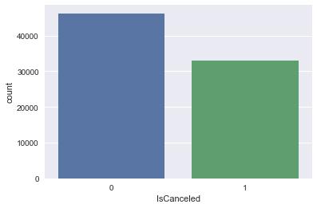

```python
sns.set(style="darkgrid")
ax = sns.countplot(x="IsCanceled", data=df)
```

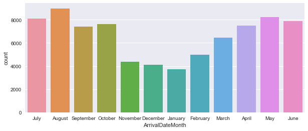

```python
plt.figure(figsize=(10, 4))
sns.set(style="darkgrid")
ax = sns.countplot(x="ArrivalDateMonth", data=df)
```

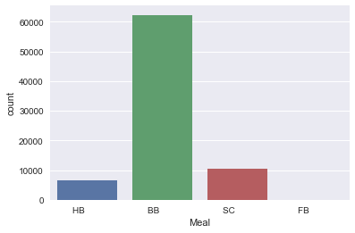

```python
sns.set(style="darkgrid")
ax = sns.countplot(x="Meal", data=df)
```

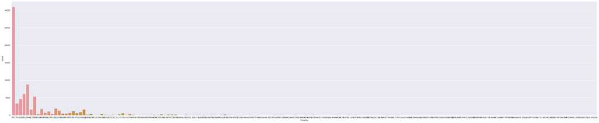

```python
plt.figure(figsize=(50,10))
sns.set(style="darkgrid")
ax = sns.countplot(x="Country", data=df)
```

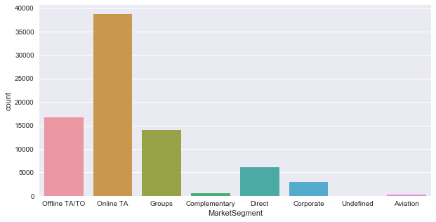

```python
plt.figure(figsize=(10,5))
sns.set(style="darkgrid")
ax = sns.countplot(x="MarketSegment", data=df)
```

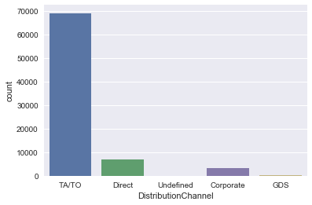

```python
sns.set(style="darkgrid")
ax = sns.countplot(x="DistributionChannel", data=df)
```

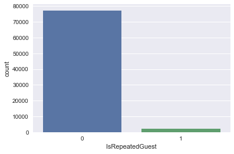

```python
sns.set(style="darkgrid")
ax = sns.countplot(x="IsRepeatedGuest", data=df)
```

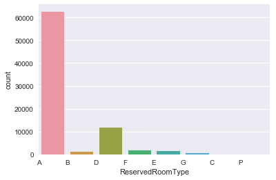

```python
sns.set(style="darkgrid")
ax = sns.countplot(x="ReservedRoomType", data=df)
```

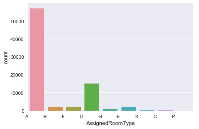

```python
sns.set(style="darkgrid")
ax = sns.countplot(x="AssignedRoomType", data=df)
```

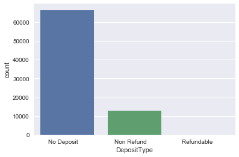

```python
sns.set(style="darkgrid")
ax = sns.countplot(x="DepositType", data=df)
```

[figure not shown]

```python
plt.figure(figsize=(100,15))
sns.set(style="darkgrid")
ax = sns.countplot(x="Agent", data=df)
```

[figure not shown]

```python
plt.figure(figsize=(100,15))
sns.set(style="darkgrid")
ax = sns.countplot(x="Company", data=df)
```

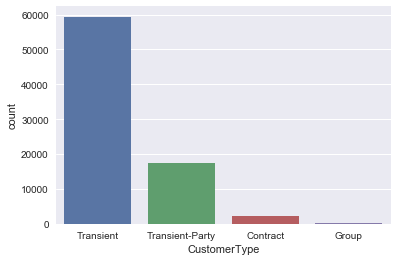

```python
sns.set(style="darkgrid")
ax = sns.countplot(x="CustomerType", data=df)
```

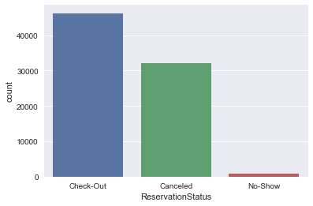

```python
sns.set(style="darkgrid")
ax = sns.countplot(x="ReservationStatus", data=df)
```

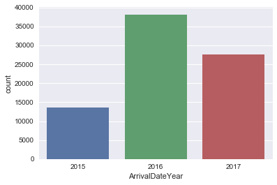

```python
ax = sns.countplot(x="ArrivalDateYear", data=df)
```

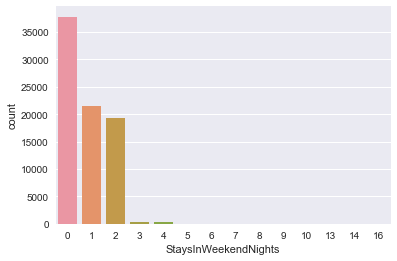

```python
ax = sns.countplot(x="StaysInWeekendNights", data=df)
```

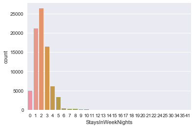

```python
ax = sns.countplot(x="StaysInWeekNights", data=df)
```

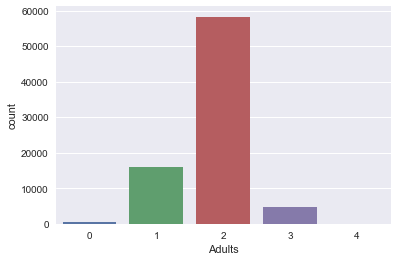

```python
ax = sns.countplot(x="Adults", data=df)
```

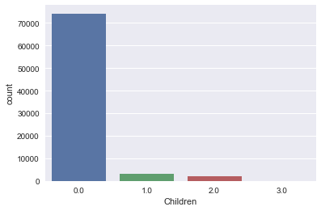

```python
ax = sns.countplot(x="Children", data=df)
```

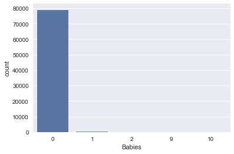

```python
ax = sns.countplot(x="Babies", data=df)
```

```python
df['kids']=df['Children']+df['Babies']
df['kids'].head()
```

```
0    0.0
1    0.0
2    0.0
3    0.0
4    0.0
Name: kids, dtype: float64
```

```python
df.groupby(['Adults','Children'])['IsCanceled'].count()
```

```
Adults  Children
0       0.0           167
        1.0             4
        2.0           208
        3.0            11
1       0.0         15570
        1.0           199
        2.0           108
        3.0             2
2       0.0         53810
        1.0          2715
        2.0          1681
        3.0            46
3       0.0          4642
        1.0           105
        2.0            27
4       0.0            31
Name: IsCanceled, dtype: int64
```

```python
df.groupby(['Adults','Babies'])['IsCanceled'].count()
```

```
Adults  Babies
0       0           387
        1             3
1       0         15872
        1             6
        9             1
2       0         57900
        1           348
        2             6
        10            1
3       0          4771
        1             4
4       0            31
Name: IsCanceled, dtype: int64
```

```python
df.groupby(['Adults','kids'])['IsCanceled'].count()
```

```
Adults  kids
0       0.0       167
        1.0         4
        2.0       205
        3.0        14
1       0.0     15564
        1.0       204
        2.0       107
        3.0         3
        9.0         1
2       0.0     53523
        1.0      2946
        2.0      1717
        3.0        65
        10.0        1
3       0.0      4638
        1.0       109
        2.0        27
4       0.0        31
Name: IsCanceled, dtype: int64
```

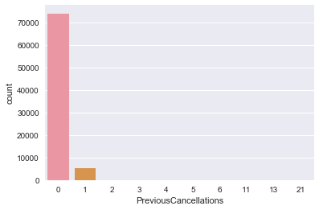

```python
ax = sns.countplot(x="PreviousCancellations", data=df)
```

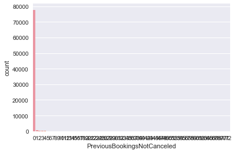

```python
ax = sns.countplot(x="PreviousBookingsNotCanceled", data=df)
```

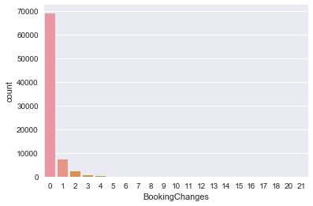

```python
ax = sns.countplot(x="BookingChanges", data=df)
```

[figure not shown]

```python
plt.figure(figsize=(100,15))
ax = sns.countplot(x="DaysInWaitingList", data=df)
```

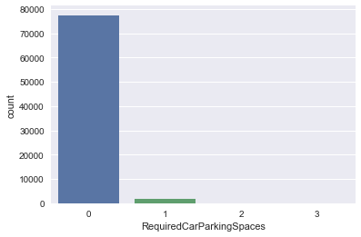

```python
ax = sns.countplot(x="RequiredCarParkingSpaces", data=df)
```

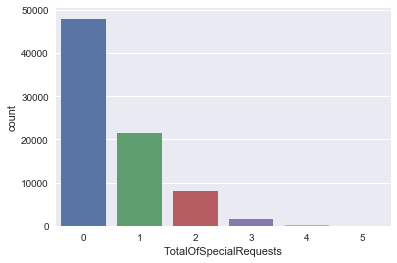

```python
ax = sns.countplot(x="TotalOfSpecialRequests", data=df)
```

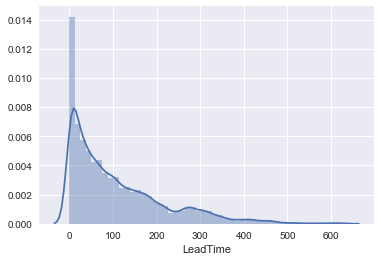

```python
ax = sns.distplot(df["LeadTime"])
```

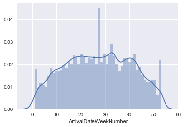

```python
ax = sns.distplot(df["ArrivalDateWeekNumber"])
```

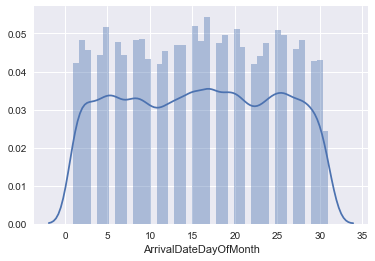

```python
ax = sns.distplot(df["ArrivalDateDayOfMonth"])
```

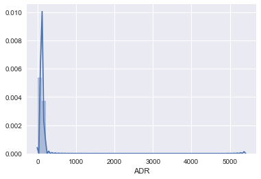

```python
ax = sns.distplot(df["ADR"])
```